# Introduction to ForeCA

Georg M. Goerg

May 21, 2020

The **ForeCA** R package implements forecastable compoenent analysis (ForeCA).

```r
library(ForeCA)
```

If you don’t know about ForeCA yet, the next section gives a quick overview. If you know ForeCA already you can skip it and go straight to the examples.

## What is ForeCA?

Forecastable component analysis (ForeCA) is a novel dimension reduction (DR) technique for multivariate time series. Similar to other DR methods **ForeCA** tries to find an “**interesting**” linear combination $y_t = \mathbf{w}' X_t$ of a multivariate time series $\mathbf{X}_t$. For principal component analysis (PCA) *high variance* data is interesting; for slow feature analysis (SFA) *slow* signals are interesting. **ForeCA** tries to find linear combinations that are easy to forecast, i.e., **forecastable** – hence the name.

The measure of forecastability, denoted as $\Omega(y_t)$, is based on the spectral entropy of $y_t$, i.e., the entropy of the spectral density $f_y(\lambda)$: high entropy means low forecastability; low entropy signals are easy to forecast.

For more details please see the ForeCA paper(s):

```r
citation("ForeCA")
```

```
##
## If you use 'ForeCA' in your publication please cite both the 'ForeCA' R
## package as well as the ForeCA article in JMLR:
##
##   Georg M. Goerg (2020). ForeCA: An R package for Forecastable
##   Component Analysis. R package version 0.2.7.
##
##   Georg M. Goerg: Forecastable Component Analysis. JMLR, W&CP (2) 2013:
##   64-72.
##
## To see these entries in BibTeX format, use 'print(<citation>,
## bibtex=TRUE)', 'toBibtex(.)', or set
## 'options(citation.bibtex.max=999)'.
```

# Specifying estimation settings

ForeCA uses two main estimation techniques:

- spectral density estimation of multivariate (or univariate) time series $\mathbf{X}_t$ (or $y_t$);
- Shannon entropy estimation of a univariate probability mass function.

The **ForeCA** package achieves this via

- **astsa** package for good non-parametric estimates of the spectrum, and
- simple plugin estimates of Shannon entropy (`discrete_entropy` / `continuous_entropy`) with optional prior smoothing.

In this package details of those two estimator are specified via `spectrum.control` and `entropy.control` arguments (lists). For sake of simplicity let’s fix them here and use those settings all throughout the examples.

```r
# spectrum control
sc <- list(method = "mvspec")
# entropy control
ec <- list(prior.weight = 1e-2)
```

For more options and detailed explanations see `?complete-controls`.

# Example: European stock market data

```r
data("EuStockMarkets")
```

The `EuStockMarkets` data contains daily closing prices for 4 major European stock markets. As usual we convert this to log-returns to make the time series stationary.

```r
# log-returns in %
ret <- diff(log(EuStockMarkets)) * 100
```

## Time series EDA

`ret` contains time series of 4 major European stock indices (see `?EuStockMarkets` for details).

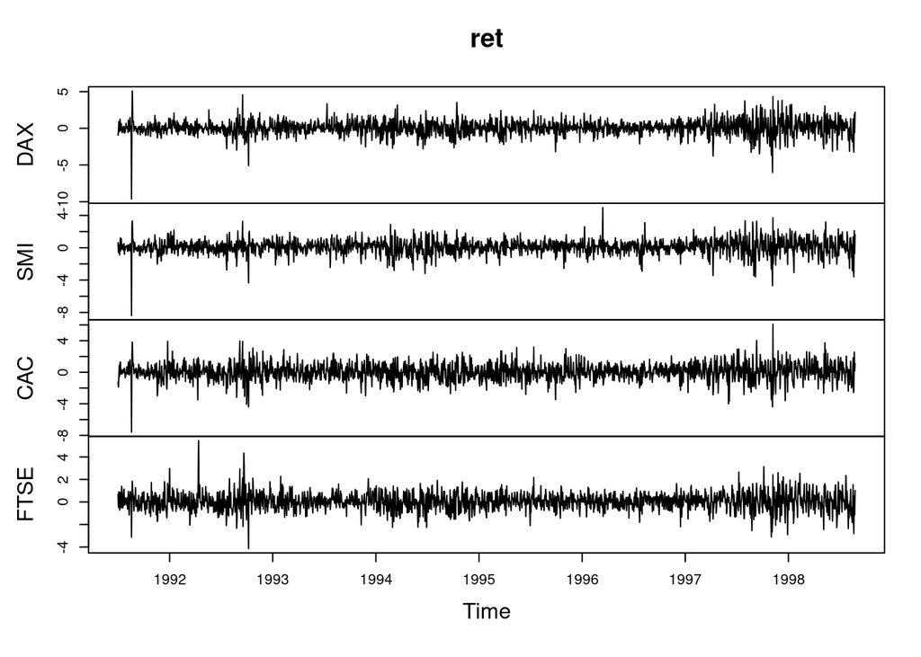

```r
cor.ret <- cor(ret)
kable(format(cor.ret, digits = 2),
      caption = "Correlation matrix")
```

Correlation matrix

|  | DAX | SMI | CAC | FTSE |
| --- | --- | --- | --- | --- |
| DAX | 1.00 | 0.70 | 0.73 | 0.64 |
| SMI | 0.70 | 1.00 | 0.62 | 0.58 |
| CAC | 0.73 | 0.62 | 1.00 | 0.65 |
| FTSE | 0.64 | 0.58 | 0.65 | 1.00 |

```r
kable(format(solve(cor.ret), digits = 2),
      caption = "Conditional covariance given other variables")
```

Conditional covariance given other variables

|  | DAX | SMI | CAC | FTSE |
| --- | --- | --- | --- | --- |
| DAX | 2.90 | -1.03 | -1.18 | -0.49 |
| SMI | -1.03 | 2.14 | -0.31 | -0.40 |
| CAC | -1.18 | -0.31 | 2.51 | -0.69 |
| FTSE | -0.49 | -0.40 | -0.69 | 1.99 |

The correlation matrix shows that they are highly correlated with each other and the partial autocorrelation function (PACF) and spectra show that they are slightly autocorrelated.

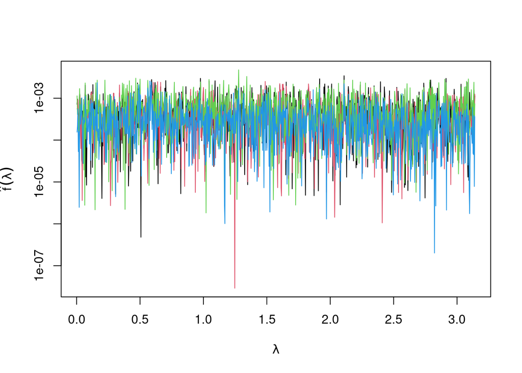

```r
ret.spec <- mvspectrum(ret, spectrum.control = sc)
plot(ret.spec)
```

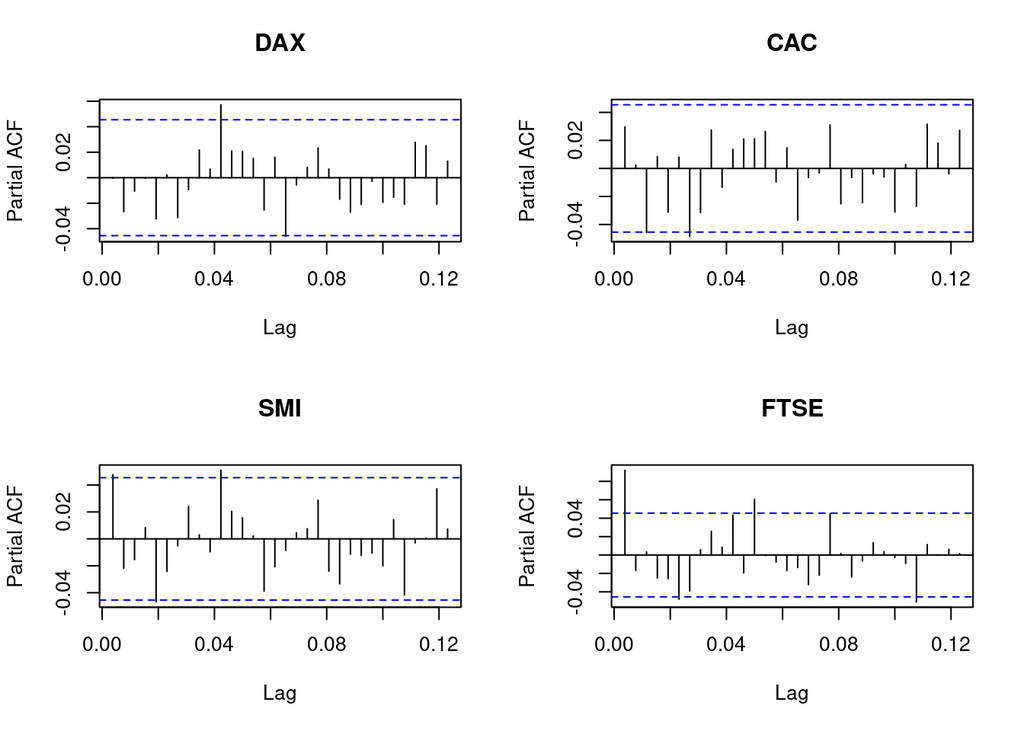

```r
layout(matrix(seq_len(ncol(ret)), ncol = 2))
for (nn in colnames(ret)) {
  pacf(ret[, nn], main = nn)
}
```

Not surprisingly the PACF shows only very small partial correlations, since these are stock market return and we should not expect see too large correlations over time (cf. [“no arbitrage” hypothesis](http://en.wikipedia.org/wiki/Arbitrage)).

More specifically, we can estimate ForeCA measure of forecastability, $\Omega$, for each series:

```r
ret.omega <- Omega(ret, spectrum.control = sc, entropy.control = ec)
ret.omega
```

```
##      DAX      SMI      CAC     FTSE
## 5.353323 5.135365 4.966076 5.253096
## attr(,"unit")
## [1] "%"
```

According to the estimates CAC is the least forecastable, DAX is the most forecastable stock market.

However, we can ask if there are linear combinations of stock markets, i.e., a *portfolio*, that are even easier to forecast. That’s exactly what ForeCA is doing.

## foreca(): find forecastable components

The main function in the package is `foreca()`, which should be straightforward to use as it resembles `princomp` for PCA or `fastICA` for independent component anlaysis (ICA). In the basic setting users only have to pass the multivariate time series and the number of components (`n.comp` – by default it uses `2`). We also specify `spectrum.control` and `entropy.control` but this is optional.

```r
mod.foreca.ret <- foreca(ret, n.comp = ncol(ret),
                         spectrum.control = sc,
                         entropy.control = ec)
```

```r
mod.foreca.ret  # this uses the print.foreca method
```

```
## ForeCA found the top 4 ForeCs of 'ret' (4 time series).
## Out of the top 4 ForeCs, 1 are white noise.
##
## Omega(ForeC 1) = 6.2% vs. maximum Omega(ret) = 5.35%.
## This is an absolute increase of 0.85 percentage points (relative: 15.89%) in forecastability.
##
## * * * * * * * * * *
## Use plot(), biplot(), and summary() for more details.
```

For ease of use and better integration with existing methods in R, the returned `foreca` objects are very similar to `princomp` objects, i.e., they have `$scores` and `$loadings` (and many other useful metrics).

```r
str(mod.foreca.ret) # too much to display; try it out!
```

The console print out showed that ForeCA indeed worked and it could find linear combinations that were more forecastable than any of the original series. The $\Omega$ score of the forecastable components (ForeCs) are

```r
mod.foreca.ret$Omega
```

```
##   ForeC1   ForeC2   ForeC3   ForeC4
## 6.204139 6.072493 5.732149 5.054154
```

Recall that the most forecastable original time series had $\hat{\Omega} = 5.35$ (use `summary(mod.foreca.ret)$Omega.orig)` to get them). The loadings of the ForeCs tell us what this forecastable portfolio looks like:

```r
mod.foreca.ret$loadings
```

```
##
## Loadings:
##      ForeC1 ForeC2 ForeC3 ForeC4
## DAX   1.548  0.287         0.505
## SMI  -0.882  0.720 -1.098
## CAC  -0.829  0.115  1.047  0.512
## FTSE        -1.677 -0.566
##
##                ForeC1 ForeC2 ForeC3 ForeC4
## SS loadings     3.866  3.426  2.623  0.530
## Proportion Var  0.967  0.856  0.656  0.132
## Cumulative Var  0.967  1.823  2.479  2.611
```

# S3 methods

The **ForeCA** package implements several `S3` methods for objects of class `foreca` so that results can be quickly visualized and easily interpreted.

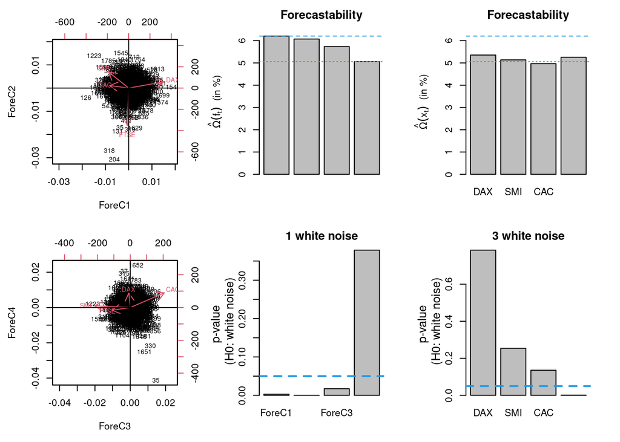

```r
plot(mod.foreca.ret)
```

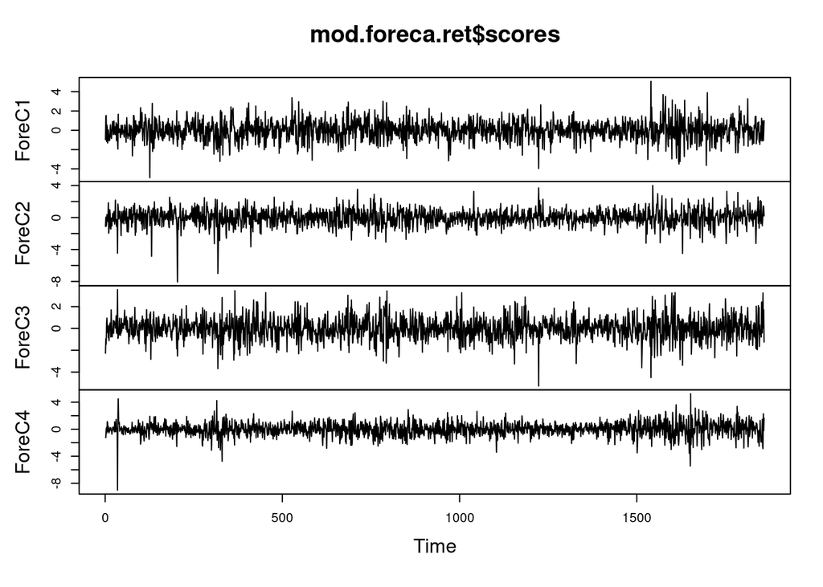

```r
plot(mod.foreca.ret$scores)
```

By design of ForeCA, the returned series are uncorrelated and have zero mean and unit variance.

```r
round(colMeans(mod.foreca.ret$scores), 3)
```

```
## ForeC1 ForeC2 ForeC3 ForeC4
##      0      0      0      0
```

```r
kable(round(cov(mod.foreca.ret$scores), digits = 3))
```

|  | ForeC1 | ForeC2 | ForeC3 | ForeC4 |
| --- | --- | --- | --- | --- |
| ForeC1 | 1 | 0 | 0 | 0 |
| ForeC2 | 0 | 1 | 0 | 0 |
| ForeC3 | 0 | 0 | 1 | 0 |
| ForeC4 | 0 | 0 | 0 | 1 |